# Дискриминантный анализ

Литвинцев И.С

10 декабря 2017 г

## I. Линейный дискриминантный анализ

Исследуются данные о недоношенных младенцах, у которых вовремя не закрылся артериальный проток.

Построить процедуры линейной классификации по восьми независимым признакам, прогнозирующим бронхо-лёгочную дисплазию.

Требуется

Независимые признаки:

1. O2.1 Насыщение крови кислородом до
2. O2.2 Насыщение крови кислородом после
3. Diuresis1 Диурез до
4. Diuresis.2 Диурез после
5. PA1 Артериальное давление до
6. PA2 Артериальное давление после
7. Р.Р.1 Пульсовое давление до
8. PP2 Пульсовое давление после

Прогнозируемая переменная (осложнения):

1. BLD Бронхо лёгочная дисплазия

2) RN ретинопатия 3) IVB Осложнения ЖКТ 4) NEC Сепсис 5) Outcome Смерть: 1 - выжил

### 1. Подготовка данных

```r
file <- "C:/Users/806263/Desktop/SPbU/Магистратура Матмех (2017-2019)/Применение статистических методов к реальным данным/Данные/baseMA.csv";
df <- read.csv(file, sep = ";", dec = ".")

features <- c("O2.1", "O2.2", "Diuresis1", "Diuresis.2", "PA1", "PA2", "Р.Р.1", "PP2")

df <- subset(df, select = c(O2.1, O2.2, Diuresis1, Diuresis.2, PA1, PA2, Р.Р.1, PP2, BLD))

df <- na.omit(df)
classes <- c("BLD") #, "RN", "IVB", "NEC", "Outcome")
```

```r
k <- list()
p <- length(features)

for(class in classes){
  df[[class]] <- as.numeric(df[[class]] >= 1)
  df[[class]] <- as.factor(df[[class]])
  k[[class]] <- length(unique(df[[class]]))
  df[[class]] <- as.factor(df[[class]])
}

head(df)
```

```
##   O2.1 O2.2 Diuresis1 Diuresis.2 PA1 PA2 Р.Р.1 PP2 BLD
## 1 0.25 0.30      4.43       1.98  45  53    14  25   1
## 2 0.45 0.21      8.00       7.10  47  43    34  32   1
## 5 0.25 0.30      7.50       3.90  40  77    28  23   1
## 6 0.25 0.21      6.46       5.10  53  57    28  20   1
## 7 0.30 0.21      4.03       4.88  66  63    34  23   0
## 8 0.30 0.21      3.55       4.71  46  47    26  26   0
```

### 2. Строим дискриминантную функцию

Теперь мы можем выделить группы индивидов, принадлежащих разным классам. Подсчитаем количество индивидов в каждом классе.

```r
X <- list()
n <- list()

for(class in classes){
  X[[class]] <- split(df, df[[class]])
  for(name in names(X[[class]])){
    if(nrow(X[[class]][[name]]) > 1){
      n[[class]][[name]] <- nrow(X[[class]][[name]])
    }
  }
}
```

Найдем $N$ – число всех индивидов.

```r
N <- nrow(df); N
```

```
## [1] 107
```

```r
rownames(df) <- 1:nrow(df)
```

Найдем оценки векторов средних и объединенную выборочную ковариационную матрицу.
$$\bar{X}_i = \frac{1}{n_i} \sum_{j=1}^{n_i} (X_i)_j, \qquad i \in 1:p$$
Если $\mathrm{X}_i$ – матрица центрированных данных, то выборочная ковариационная матрица ищется по формуле.
$$S_i = \frac{(\mathrm{X}_i)^T\mathrm{X}_i}{n_i - 1}$$
А в качестве объединенной выборочной ковариационной матрицы используем выражение:
$$S = \frac{ \sum_{i=1}^k (n_i - 1)S_i}{ \sum_{i=1}^k n_i - k}$$

```r
means <- list()
S.i <- list()
S <-  list()

for(class in classes){
  S[[class]] <- matrix(0, p, p)

  for(name in names(n[[class]])){
    data.mat <- X[[class]][[name]][ , features]
    # аргумент 2 означает, что на вход функции mean подаются строки датафрейма X[[class]]
    means[[class]][[name]] <- apply(data.mat, 2, mean)

    #data.mat <- scale(data.mat) #стандартизация, но с ней результат не совпадает с lda

    S.i[[class]][[name]] <-  cov(data.mat)
    S[[class]] <- S[[class]] + S.i[[class]][[name]]*(n[[class]][[name]] - 1)
  }
  S[[class]] <- S[[class]]/(N - k[[class]])
}
```

Введем дискриминантную функцию
$$\delta_i = \alpha_i^T X + \gamma_i + \ln q_i,$$
где $\alpha_i = \Sigma^{-1}\mu_i$, $\gamma_i = -\frac{1}{2}\mu_i^T\Sigma^{-1}\mu_i$ на генеральном языке. Или тоже самое на выборочном $\alpha_i = S^{-1}\bar{X}_i$, $\gamma_i = \bar{X}_i^T S^{-1} \bar{X}_i$ и $q_i = \frac{n_i}{\sum_{i=1}^k n_i}$.

Найдем $\alpha_i$, $\gamma_i$ и $q_i$:

```r
alpha <- list(); gamma <- list(); q <- list();
S.inv <- list()

for(class in classes){
  S.inv[[class]] <- solve(S[[class]])
  m <- means[[class]]
  for(name in names(n[[class]])){
    alpha[[class]][[name]] <- S.inv[[class]]%*%m[[name]]
    gamma[[class]][[name]] <- -(t(m[[name]])%*%S.inv[[class]]%*%m[[name]])/2
    q[[class]][[name]] <- n[[class]][[name]]/N
  }
}
```

Наконец, определим дискриминантную функцию $\delta_i = \alpha_i^T X + \gamma_i + \ln q_i:$

```r
delta <- function(x, alpha, gamma, q){
  delta <- c()
  for(name in names(alpha)){
    a <- as.matrix(alpha[[name]])
    delta <- append(delta, t(x)%*%a + gamma[[name]] + log(q[[name]]));
  }
  return(delta)
}
```

### 3. Проверка результатов с помощью функции lda()

Воспользуемся встроенной фукнцией lda() для проверки результатов.

```r
library(MASS)

res.lda <- lda(BLD ~ ., df[ , rbind(as.matrix(features), "BLD")]); res.lda
```

```
## Call:
## lda(BLD ~ ., data = df[, rbind(as.matrix(features), "BLD")])
##
## Prior probabilities of groups:
##         0         1
## 0.2990654 0.7009346
##
## Group means:
##      O2.1    O2.2 Diuresis1 Diuresis.2      PA1      PA2    Р.Р.1     PP2
## 0 0.26875 0.27375  5.275938   5.702187 48.25000 53.09375 25.78125 28.4375
## 1 0.36040 0.38200  6.002533   7.601067 50.65333 53.32000 27.25333 28.0400
##
## Coefficients of linear discriminants:
##                     LD1
## O2.1        3.244809579
## O2.2        2.779989168
## Diuresis1   0.140630075
## Diuresis.2  0.220435407
## PA1         0.007918718
## PA2         0.004132966
## Р.Р.1       0.030239229
## PP2        -0.023215173
```

Подадим выборку на вход полученной функции для предсказания.

```r
lda.pred <- predict(res.lda, df[ , rbind(as.matrix(features), "BLD")])$class
```

Теперь, используя построенную нами дискриминантную функцию, классифицируем все элементы выборки.

```r
delta.values <- matrix(0, N, k$BLD)
delta.pred <- c()

for(i in 1:N){
  delta.values[i,] <- delta(t(df[i , features]), alpha$BLD, gamma$BLD, q$BLD)
  delta.pred[i] <- which.max(delta.values[i, ])-1
}
```

Сравним полученным результаты двух предсказаний между собой и с реальными значениями.

```r
predictions.df <- data.frame(lda=lda.pred, my.lda=delta.pred, real=df[ , "BLD"]);

lda.pred <- as.numeric(lda.pred)
delta.pred <- as.numeric(delta.pred)

t1 <- table(real=df[ , "BLD"], lda=lda.pred); t1
```

```
##     lda
## real  1  2
##    0 17 15
##    1  5 70
```

```r
t2 <- table(real=df[ , "BLD"], my.lda=delta.pred); t2
```

```
##     my.lda
## real  0  1
##    0 17 15
##    1  5 70
```

```r
t3 <- table(lda=lda.pred, my.lda = delta.pred); t3
```

```
##    my.lda
## lda  0  1
##   1 22  0
##   2  0 85
```

Оценим вероятность правильных классификаций:

```r
t1.quality <- sum(diag(t1))/N
t2.quality <- sum(diag(t2))/N
predictions.quality <- data.frame(lda.p=t1.quality, my.lda.p=t2.quality); predictions.quality
```

```
##       lda.p  my.lda.p
## 1 0.8130841 0.8130841
```

Оценим вероятность ошибочных классификаций:
$$P(2|1) = \frac{m_1}{n_1}, \qquad P(1|2)=\frac{m_2}{n_2},$$
где $m_1$ – число индивидов из популяции $W_1$, которые на основе процедуры классификации относятся к популяции $W_2$; $m_2$ определяется аналгично.

```r
m1 <- t2[1,2];
m2 <- t2[2,1];
data.frame(P21=m1/n$BLD[1], P12=m2/n$BLD[2])
```

```
##       P21        P12
## 0 0.46875 0.06666667
```

Можно сделать вывод, что гораздо вероятней неправильно классифицировать индивида из первого класса, нежели из второго.

Чтобы убделиться, что дискриминантная фунция построена верно, посчитаем корреляции векторов коэффициентов, найденных вручную, с векторами коэффициентов, полученных с помощью встроенной функцией.

```r
cor(alpha$BLD$`1`-alpha$BLD$`0`, res.lda$scaling[ ,1])
```

```
##      [,1]
## [1,]    1
```

Видимо, что коэффициенты положительно коррелируют.

### 4. Апостериорная вероятность

Найдем индивидов, которые были неправильно классифицированы.

```r
ind.mistakes <- (predictions.df[, 1] != predictions.df[, 3])
data.mistakes <-  df[ind.mistakes, features ]
nrow(data.mistakes)
```

```
## [1] 20
```

Посчитаем апостериорную вероятность для неправильно классифицированных данных по формуле
$$P(W_i | x) = \frac{e^{\delta_i}}{\sum_{j=1}^{k}e^{\delta_j}}$$

```r
p.aposter <- exp(delta.values[ind.mistakes,])/rowSums(exp(delta.values[ind.mistakes,]))

head(p.aposter)
```

```
##           [,1]      [,2]
## [1,] 0.7902855 0.2097145
## [2,] 0.4284298 0.5715702
## [3,] 0.2122090 0.7877910
## [4,] 0.5608206 0.4391794
## [5,] 0.3508912 0.6491088
## [6,] 0.4397274 0.5602726
```

Построим scatter plot значений дискриминантов

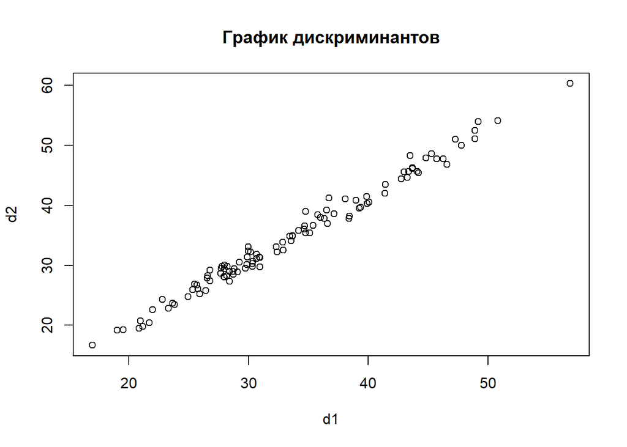

```r
plot(delta.values[ , 1], delta.values[, 2], main="График дискриминантов",
   xlab="d1", ylab="d2", pch=1)
```

### 5. Значимость классификации

Проверим гипотезу о том, что различие между классами значимо:
$$H_0: \mu_1 = \mu_2$$
Для ее проверки используют статистику вида:
$$F = \frac{n_1 + n_2 - p -1}{(n_1 + n_2 - 2)p}\frac{n_1n_2}{n_1 + n_2} D^2 \sim F(p, \: n_1+n_2-p-1)$$
где $D^2$ – выборочное расстояние Махаланобиса
$$D^2= \frac{(\bar{z}_1 - \bar{z}_2)^2}{s_z^2}, \qquad \bar{z}_i = \alpha^T\bar{X}_i, \qquad s_z^2=\alpha^T S\alpha^T, \qquad \alpha = (\bar{X}_1 - \bar{X}_2)^TS^{-1}$$

```r
a <- t((means$BLD$`0` - means$BLD$`1`))%*%(S.inv$BLD); a
```

```
##          O2.1      O2.2  Diuresis1 Diuresis.2          PA1          PA2
## [1,] -3.87038 -3.315946 -0.1677423 -0.2629334 -0.009445377 -0.004929765
##            Р.Р.1        PP2
## [1,] -0.03606909 0.02769085
```

```r
z0 <- a%*%means$BLD$`0`
z1 <- a%*%means$BLD$`1`
s <- a%*%S$BLD%*%t(a)
D2 <- (z0-z1)^2/s
n1 <- n$BLD[1]; n2 <- n$BLD[2]
f <- ((n1+n2-p-1)/((n1+n2-2)*p))*((n1*n2)/(n1+n2))*D2
pvalue <- 1 - pf(f, p, n1+n2-p-1); pvalue
```

```
##              [,1]
## [1,] 0.0007718092
```

При уровне значимости 0.05 получаем значимую разницу классов.

### 6. Выделение подмножества признаков для наилучшего разделения классов

Для решения этой задачи можно использовать пошаговый дискриминантный анализ, а можно методом перебора всех сочетаний признаков найти такое сочетание, для которого имеет место наилбольшая вероятность правильной классификации.

```r
#install.packages('gtools')
library(gtools)

df.combinations <- data.frame()

for(i in 1:p){
  features.combination <- combinations(n=p, r=i, v=features)
  for(j in 1:nrow(features.combination)){
    train <- df[ , rbind(as.matrix(features.combination[j,]), "BLD")]
    res.lda <- lda(BLD ~ ., train);
    predict.lda <- predict(res.lda, train)$class
    tab <- table(real=df[ , "BLD"], lda=predict.lda);
    pred.quality  <- sum(diag(tab))/N;

    features.str <- paste(features.combination[j,],collapse=", ")
    df.tmp <- data.frame(features=features.str, quality= pred.quality)
    df.combinations <- rbind(df.combinations, df.tmp)
  }
}

df.combinations <- df.combinations[order(df.combinations$quality, decreasing = T), ]
head(df.combinations)
```

```
##                                                    features   quality
## 224           Diuresis.2, Diuresis1, O2.1, O2.2, PP2, Р.Р.1 0.8317757
## 223           Diuresis.2, Diuresis1, O2.1, O2.2, PA2, Р.Р.1 0.8224299
## 166                Diuresis.2, Diuresis1, O2.1, O2.2, Р.Р.1 0.8130841
## 250      Diuresis.2, Diuresis1, O2.1, O2.2, PA2, PP2, Р.Р.1 0.8130841
## 253            Diuresis.2, O2.1, O2.2, PA1, PA2, PP2, Р.Р.1 0.8130841
## 255 Diuresis.2, Diuresis1, O2.1, O2.2, PA1, PA2, PP2, Р.Р.1 0.8130841
```

Видим, что наилучшее качество классификации с вероятностью 0.83 достигается на 6 следующих признаках: Diuresis.2, Diuresis1, O2.1, O2.2, PP2, Р.Р.1

- O2.1 Насыщение крови кислородом до
- O2.2 Насыщение крови кислородом после
- Diuresis1 Диурез до
- Diuresis.2 Диурез после
- Р.Р.1 Пульсовое давление до
- PP2 Пульсовое давление после

## II. Классификация в случае биномиальных распределений

Имеется 5 дихотомических признаков:

1. Sex,
2. Alone Breathing,
3. Hemotransfusion,
4. Horm,
5. IN,

И дискриминантная переменная:

1. бронхо-лёгочная дисплазия,

2) осложнения ЖКТ, 3) ретинопатия, 4) сепсис, 5) невозможное самостоятельное закрытие протока, 6) смерть.

Требуется провести дискриминатнтый анализ для качественных признаков.

### 1. Подготовка данных

```r
df <- read.csv(file, sep = ";", dec = ".")

features <- c("Sex", "Alone.Breathing", "Hemotransfusion", "Horm", "IN")
df.features <- subset(df, select = features)
df.class <- df$BLD
df <- cbind(df.features, "BLD"=df.class)
df <- na.omit(df)

classes <- c("BLD")

head(df)
```

```
##    Sex Alone.Breathing Hemotransfusion Horm IN BLD
## 13   1               0               1    0  1   0
## 16   1               1               1    0  0   1
## 18   2               1               1    0  1   0
## 21   2               0               1    1  1   2
## 22   1               0               0    0  1   3
## 23   1               0               1    0  1   1
```

```r
df$Sex <- df$Sex - 1
df$BLD <- as.factor(df$BLD)
```

Решается задача отнесения объекта к одной из $k$ популяций $W_1, \ldots, W_k$ с биномиальным распределением с известными априорными вероятностями $q_1, \ldots, q_k$. Положим
$$P(X_j = 1 | W_i ) = p_{ij}, \qquad P(X_j = 0 | W_i ) = 1 - p_{ij}, \qquad i \in 1:k, \; j \in 1:p.$$
Тогда закон распределения имеет вид
$$f_i(x_j) = p_{ij}^{x_j}(1-p_{ij})^{1 - x_j}, \qquad x_j \in \{0, 1 \}$$
При независимости признаков $X_1, \ldots, X_p$ совместный закон распределения имеет вид
$$f_i(x) = f_i(x_1) \cdot \ldots \cdot f_i(x_p), \qquad i\in 1:k, \quad x = (x_1, \ldots, x_p)^T.$$
Вектор $x$ относится к популяции $W_i$ с максимальной величиной апостериорной вероятности, которая при одинаковой стоимости ошибочной классификации имеет вид:
$$P(W_i | x) = \frac{q_i f_i(x)}{\sum_{m=1}^k q_m f_m(x)}$$
Пусть $n_{i}$ число индивидов из популяции $W_i$, из них $n_{ij}$ имеют $j$-ый признак. Тогда оценка $\hat{p}_{ij}=n_{ij}/n_i$. Если априорные вероятности неизвестны, то их оценками являются $\hat{q}_i = n_i/n$, где $n_1 + \ldots + n_k = n$.

Найдем число признаков, чисо классов и разобьем даные на группы с помощью уровней дискриминантного признака.

```r
p <- length(features)
k <- length(unique(df$BLD))
n <- nrow(df)
rownames(df) <- 1:n # перенумеровали строки
X <- split(df[ , features], df$BLD)
```

Посчитаем $n_i$, $n_{ij}$, $\hat{q}_i$, $p_{ij}$:

```r
ni <- list(); nij <- list(); q <- list()
pij <- list()

for(class in names(X)){
  nij[[class]] <- colSums(X[[class]][, features])
  ni[[class]] <- nrow(X[[class]])
  q[[class]] <- ni[[class]]/n
  pij[[class]] <- nij[[class]]/ni[[class]]
}
```

Построим функцию $f_i(x)$:

```r
fij <- function(pij, xj){
  fij <- (pij^xj)*(1 - pij)^(1-xj)
  return(fij)
}

fi <- function(pij, x){
  fi <- 1;
  for(j in 1:length(x)){
    fi <- fi*fij(pij[j], x[j])
  }
  return(fi)
}
```

Основываясь на формуле апостериорной вероятности $P(W_i | x) = \frac{q_i f_i(x)}{\sum_{m=1}^k q_m f_m(x)}$, найдем к какому классу принадлежат индивиды нашей выборки.

```r
aposter.mat <- matrix(0, n, k)
for(j in 1:n){
  for(i in 1:k){
    aposter.mat[j, i] <- q[[i]]*fi(pij[[i]], df[j, features])
  }
}

aposter.mat <- aposter.mat/rowSums(aposter.mat)

binom.pred <- c()
for(i in 1:n){
  binom.pred[i] <- which.max(aposter.mat[i, ])-1
}
head(binom.pred)
```

```
## [1] 1 0 0 1 2 1
```

### 2. Проверка результатов с помощью функции lda()

Воспользуемся встроенной фукнцией lda() для проверки результатов.

```r
res.lda <- lda(BLD ~ ., df[ , rbind(as.matrix(features), "BLD")]); res.lda
```

```
## Call:
## lda(BLD ~ ., data = df[, rbind(as.matrix(features), "BLD")])
##
## Prior probabilities of groups:
##          0          1          2          3
## 0.43434343 0.27272727 0.23232323 0.06060606
##
## Group means:
##         Sex Alone.Breathing Hemotransfusion       Horm        IN
## 0 0.3720930       0.6744186       0.3720930 0.02325581 0.5581395
## 1 0.3333333       0.2592593       0.8518519 0.07407407 0.7037037
## 2 0.2608696       0.1304348       0.6086957 0.08695652 0.7391304
## 3 0.3333333       0.0000000       0.6666667 0.16666667 0.8333333
##
## Coefficients of linear discriminants:
##                        LD1        LD2         LD3
## Sex              0.2396090  0.2663021 -1.38792445
## Alone.Breathing  2.0490099  1.2765737 -0.49373596
## Hemotransfusion -0.7520915  2.1593838  0.03504251
## Horm            -0.3359517 -0.5123010 -3.10916423
## IN               0.3228219 -0.2181393 -0.76144809
##
## Proportion of trace:
##    LD1    LD2    LD3
## 0.8265 0.1610 0.0125
```

```r
lda.pred <- predict(res.lda, df[ , rbind(as.matrix(features), "BLD")])$class
```

Сравним полученные результаты предсказаний

```r
df.compare <- data.frame(pred.class=binom.pred, real=df[ , "BLD"], lda=lda.pred)

t1 <- table(real=df[ , "BLD"], my.lda=binom.pred); t1
```

```
##     my.lda
## real  0  1  2
##    0 31 10  2
##    1  9 18  0
##    2  7 12  4
##    3  0  4  2
```

```r
t2 <- table(real=df[ , "BLD"], lda=lda.pred); t2
```

```
##     lda
## real  0  1  2  3
##    0 30 10  3  0
##    1  7 18  2  0
##    2  6 12  5  0
##    3  0  4  2  0
```

```r
t3 <- table(my.lda=binom.pred, lda=lda.pred); t3
```

```
##       lda
## my.lda  0  1  2  3
##      0 43  0  4  0
##      1  0 44  0  0
##      2  0  0  8  0
```

Оценим качество предсказаний

```r
t1.quality <- sum(diag(t1))/n;
t2.quality <- sum(diag(t2))/n;
t3.quality <- sum(diag(t3))/n;

predictions.quality <- data.frame(lda.p=t1.quality, my.lda.p=t2.quality); predictions.quality
```

```
##       lda.p  my.lda.p
## 1 0.5353535 0.5353535
```

Видим, что качество наших предсказаний такое же как качество предсказаний функции lda().